# Digital Signal Processing - Lecture 3

Discrete Fourier transform

Ewout Bergsma

Hanze University of Applied Sciences

# Overview

## Last time: input, system, output

$x[n]$

Discrete  
system

$y[n]$

$$x[n]\ast h[n]=y[n]$$

**Show plot code**

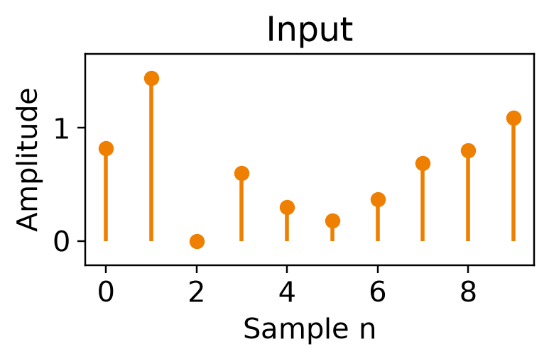

```python
x = np.array([0.82, 1.44, 0.0, 0.60, 0.30, 0.18, 0.37, 0.69, 0.80, 1.09])
fig, ax = plt.subplots(figsize=(3.4, 2.2), layout="constrained")
markers, stems, baseline = ax.stem(np.arange(len(x)), x, basefmt=" ")
plt.setp(markers, color=HANZE_ORANGE, markersize=6)
plt.setp(stems, color=HANZE_ORANGE, linewidth=1.8)
ax.set(title="Input", xlabel="Sample n", ylabel="Amplitude")
ax.margins(y=0.15)
plt.show()
```

**Show plot code**

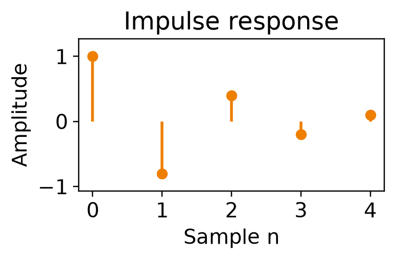

```python
h = np.array([1.0, -0.8, 0.4, -0.2, 0.1])
fig, ax = plt.subplots(figsize=(3.4, 2.2), layout="constrained")
markers, stems, baseline = ax.stem(np.arange(len(h)), h, basefmt=" ")
plt.setp(markers, color=HANZE_ORANGE, markersize=6)
plt.setp(stems, color=HANZE_ORANGE, linewidth=1.8)
ax.set(title="Impulse response", xlabel="Sample n", ylabel="Amplitude")
ax.margins(y=0.15)
plt.show()
```

**Show plot code**

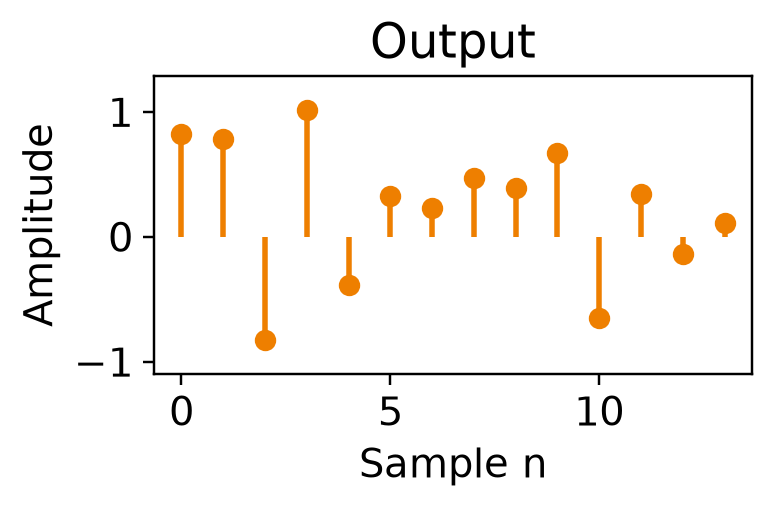

```python
x = np.array([0.82, 1.44, 0.0, 0.60, 0.30, 0.18, 0.37, 0.69, 0.80, 1.09])
h = np.array([1.0, -0.8, 0.4, -0.2, 0.1])
y = np.convolve(x, h, mode="full")
fig, ax = plt.subplots(figsize=(3.4, 2.2), layout="constrained")
markers, stems, baseline = ax.stem(np.arange(len(y)), y, basefmt=" ")
plt.setp(markers, color=HANZE_ORANGE, markersize=6)
plt.setp(stems, color=HANZE_ORANGE, linewidth=1.8)
ax.set(title="Output", xlabel="Sample n", ylabel="Amplitude")
ax.margins(y=0.15)
plt.show()
```

## Last time: moving average

**Show plot code**

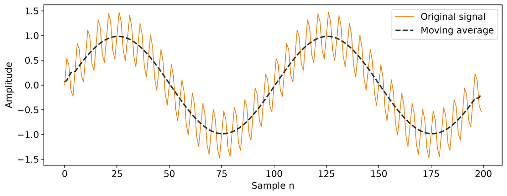

```python
n = np.arange(200)
fs = 100.0
signal = np.sin(2 * np.pi * n / fs) + 0.5 * np.sin(2 * np.pi * 20 * n / fs)
smoothed = np.convolve(signal, np.ones(10) / 10, mode="same")
fig, ax = plt.subplots(figsize=(10, 3.8), layout="constrained")
ax.plot(n, signal, color=HANZE_ORANGE, linewidth=1, label="Original signal")
ax.plot(n, smoothed, color="#263238", linewidth=2, linestyle="--", label="Moving average")
ax.set(xlabel="Sample n", ylabel="Amplitude")
ax.legend()
plt.show()
```

You did your exercises, right?

## A real-world signal

**Show plot code**

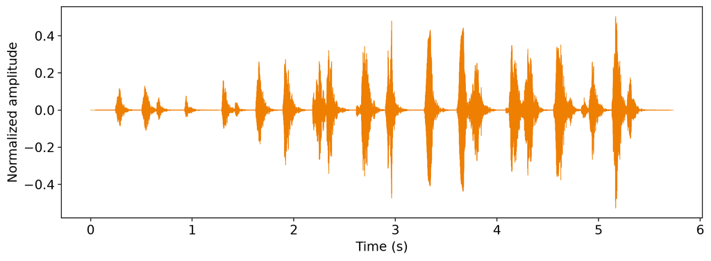

```python
time = np.arange(len(audio)) / audio_fs
fig, ax = plt.subplots(figsize=(10, 3.6), layout="constrained")
ax.plot(time, audio, color=HANZE_ORANGE, linewidth=0.5)
ax.set(xlabel="Time (s)", ylabel="Normalized amplitude")
plt.show()
```

$y[n]$ is observed. What might $x[n]$ and $h[n]$ be?

Source: https://bigsoundbank.com/detail-2776-cockatiel-parakeet-8.html

## From a sum to its components

**Show plot code**

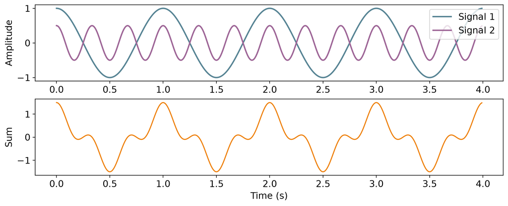

```python
time = np.arange(400) / 100.0
signal_1 = np.cos(2 * np.pi * time)
signal_2 = 0.5 * np.cos(2 * np.pi * 3 * time)
fig, axes = plt.subplots(2, 1, figsize=(10, 4), layout="constrained")
axes[0].plot(time, signal_1, color=HANZE_SECONDARY["teal"], linewidth=2, label="Signal 1")
axes[0].plot(time, signal_2, color=HANZE_SECONDARY["purple"], linewidth=2, label="Signal 2")
axes[0].set(ylabel="Amplitude")
axes[0].legend(loc="upper right")
axes[1].plot(time, signal_1 + signal_2, color=HANZE_ORANGE)
axes[1].set(xlabel="Time (s)", ylabel="Sum")
plt.show()
```

Can we identify the frequencies present in the combined signal?

## This lecture

01

Frequency domain

02

Discrete Fourier transform

03

Understanding the equation

04

Exercises

# Frequency domain

## Time domain and frequency domain

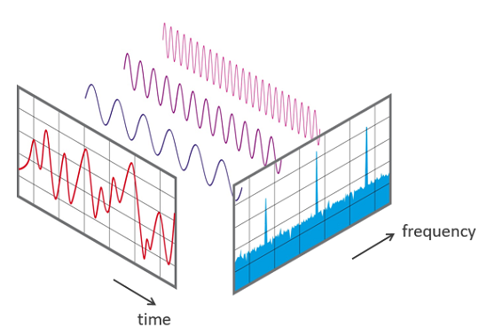

Source: https://www.nti-audio.com/en/support/know-how/fast-fourier-transform-fft

## Jean-Baptiste Joseph Fourier

[figure not shown]

**Jean-Baptiste Joseph Fourier**

Source: https://en.wikipedia.org/wiki/Joseph_Fourier

## An audio signal and its spectrum

**Show plot code**

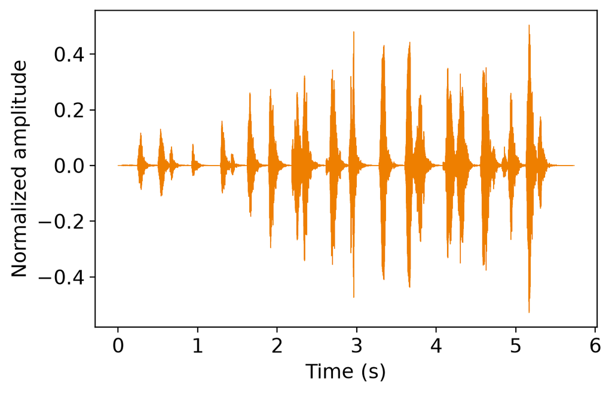

```python
time = np.arange(len(audio)) / audio_fs
fig, ax = plt.subplots(figsize=(5.5, 3.5), layout="constrained")
ax.plot(time, audio, color=HANZE_ORANGE, linewidth=0.5)
ax.set(xlabel="Time (s)", ylabel="Normalized amplitude")
plt.show()
```

**Show plot code**

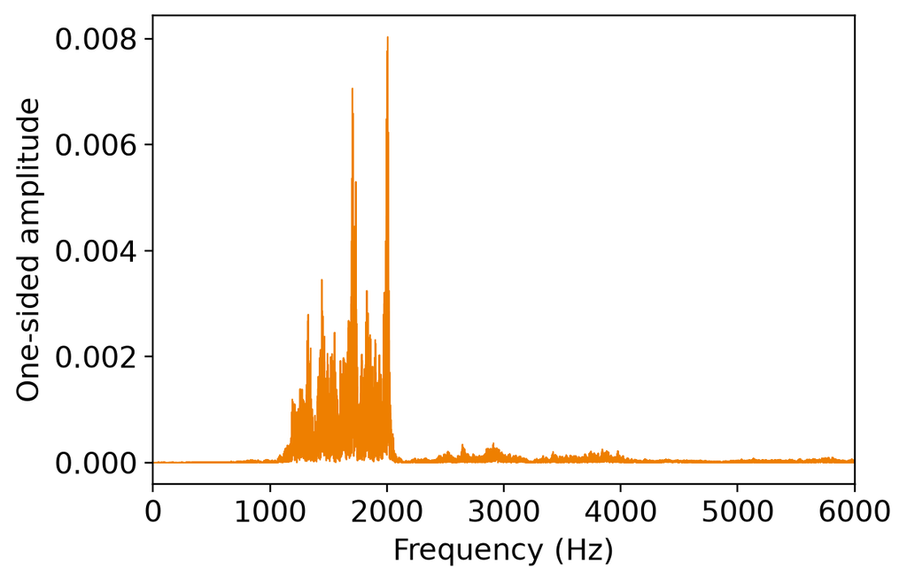

```python
coefficients = np.fft.rfft(audio)
frequencies = np.fft.rfftfreq(len(audio), d=1 / audio_fs)
amplitudes = np.abs(coefficients) / len(audio)
amplitudes[1:-1 if len(audio) % 2 == 0 else None] *= 2
fig, ax = plt.subplots(figsize=(5.5, 3.5), layout="constrained")
ax.plot(frequencies, amplitudes, color=HANZE_ORANGE, linewidth=0.7)
ax.set(xlabel="Frequency (Hz)", ylabel="One-sided amplitude", xlim=(0, min(6000, audio_fs / 2)))
plt.show()
```

Source: https://bigsoundbank.com/detail-2776-cockatiel-parakeet-8.html

# Discrete Fourier transform

## Discrete Fourier transform

$$X[k]=\sum_{n=0}^{N-1}x[n]e^{-j2\pi kn/N}$$

- $x[n]$ is a sequence of $N$ samples.
- $X[k]$ contains complex frequency-domain coefficients.

## Fourier visualisation

[video not shown]

Source: https://github.com/EwoutBergsma/Interactive-Fourier-Transform-Visualisation

## Matching a frequency

[video not shown]

Source: https://github.com/EwoutBergsma/Interactive-Fourier-Transform-Visualisation

## Separating two frequencies

[video not shown]

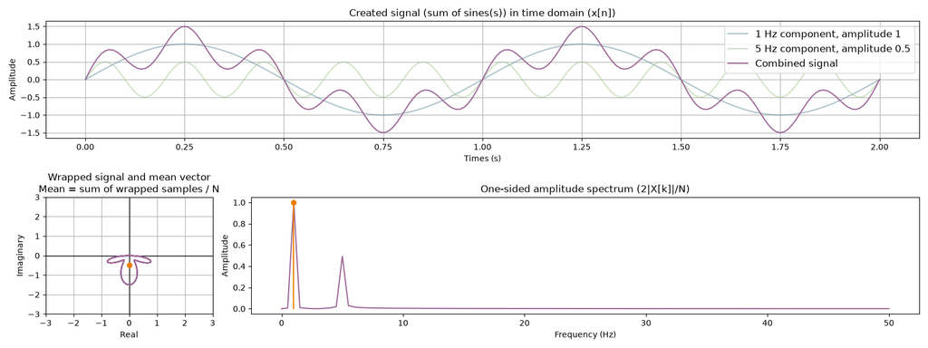

Source: https://github.com/EwoutBergsma/Interactive-Fourier-Transform-Visualisation

## From wrapped samples to DFT bins

Continuous curves

[video not shown]

Discrete data points

[video not shown]

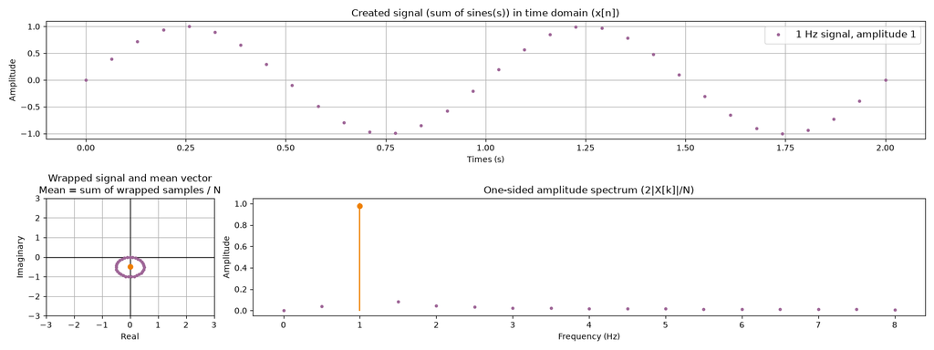

Source: https://github.com/EwoutBergsma/Interactive-Fourier-Transform-Visualisation

# Understanding the equation

## Time index and frequency index

$$\underbrace{\textcolor{#EE7F00}{X[k]}}_{\text{frequency-domain}}=\sum_{n=0}^{N-1}\underbrace{\textcolor{#EE7F00}{x[n]}}_{\text{time-domain}}e^{-j2\pi kn/N}$$

- $n$ indexes time samples.
- $k$ indexes DFT bins.

## The input samples

$$X[k]=\sum_{n=0}^{N-1}\underbrace{\textcolor{#EE7F00}{x[n]}}_{\substack{\text{input}\\\text{sample}}}e^{-j2\pi kn/N}$$

Each sample contributes to every frequency coefficient.

## The complex exponential

$$X[k]=\sum_{n=0}^{N-1}x[n]\underbrace{\textcolor{#EE7F00}{e^{-j2\pi kn/N}}}_{\text{complex sinusoid}}$$

Review complex numbers and Euler’s formula if needed.

## Euler’s formula

**Show plot code**

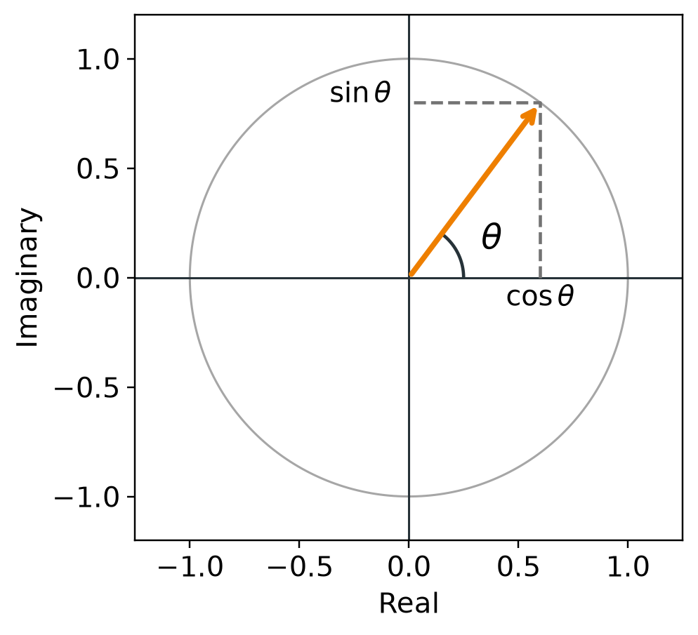

```python
theta = np.arctan2(0.8, 0.6)
angle = np.linspace(0, 2 * np.pi, 300)
fig, ax = plt.subplots(figsize=(4.5, 4), layout="constrained")
ax.plot(np.cos(angle), np.sin(angle), color="0.65", linewidth=1)
ax.axhline(0, color="#263238", linewidth=1)
ax.axvline(0, color="#263238", linewidth=1)
ax.annotate("", xy=(0.6, 0.8), xytext=(0, 0), arrowprops={"arrowstyle": "->", "color": HANZE_ORANGE, "lw": 2.5})
ax.plot([0.6, 0.6, 0], [0, 0.8, 0.8], linestyle="--", color="0.45")
arc = np.linspace(0, theta, 40)
ax.plot(0.25 * np.cos(arc), 0.25 * np.sin(arc), color="#263238")
ax.text(0.33, 0.13, r"$\theta$", fontsize=16)
ax.text(0.6, -0.13, r"$\cos\theta$", ha="center")
ax.text(-0.08, 0.8, r"$\sin\theta$", ha="right")
ax.set(xlabel="Real", ylabel="Imaginary", xlim=(-1.25, 1.25), ylim=(-1.2, 1.2), aspect="equal")
plt.show()
```

https://www.khanacademy.org/math/algebra-home/alg-complex-numbers

## One full rotation

$$X[k]=\sum_{n=0}^{N-1}x[n]e^{-j\underbrace{\textcolor{#EE7F00}{2\pi}}_{\substack{\text{one}\\\text{rotation}}}kn/N}$$

An angle of $2\pi$ radians corresponds to one revolution of the unit circle.

## The negative sign

$$X[k]=\sum_{n=0}^{N-1}x[n]e^{\overset{\textcolor{#EE7F00}{\downarrow}}{-}j2\pi kn/N}$$

The forward DFT uses the negative-exponent convention.

## Position within the sample window

$$X[k]=\sum_{n=0}^{N-1}x[n]e^{-j2\pi k\underbrace{\textcolor{#EE7F00}{n/N}}_{\text{fraction of window}}}$$

$n/N$ indicates the sample position as a fraction of the $N$-sample window.

## Selecting a frequency bin

$$X[k]=\sum_{n=0}^{N-1}x[n]e^{-j2\pi\textcolor{#EE7F00}{k}n/N}$$

- $k$ selects the frequency bin and controls the wrapping frequency.
- Increasing $k$ increases the phase change between consecutive samples.

## Sum over the samples

$$X[k]=\underbrace{\sum_{n=0}^{N-1}}_{\text{all }N\text{ samples}}x[n]e^{-j2\pi kn/N}$$

For each $k$, multiply the samples by that complex sinusoid and sum the results.

## Questions?

# Exercises

## Exercises!

Explore your signal in the frequency domain.

../exercises/DSP-Lecture-03-Exercises.ipynb